# Chapter 11 - Clustering Analysis (part 1)

## Tour Data

A questionnaire was developed to assess the importance of 55 characteristics of the bus tour operators and the tours themselves using a 5-point Likert scale (5=extremely important,…,1=not important at all). Data are available for 150 subjects (there were 817 in the article). They are in the file `cluster1.RData`.

- Social activities (`Social`): made up of 5 items
- Operator’s policies and references (`Policy`): made up of 6 items.
- Flexible hours (`Hours`): composed of 3 items.
- Health and Safety (`Safety`): made up of 4 items.
- Advertising material (`Advertising`): composed of 2 items.
- Reputation (`Reputation`): made up of 2 items.

We can see that 22 items, among the 55, are used in the definition of these 6 factors. In the article, the authors decided to include these 22 items in the the clustering analysis. For our part and in order to simplify the example we will instead create 6 new scales (variables) by averaging the items of each of the above factors and use only these 6 scales (thus 6 variables) in the cluster analysis. The values of these 6 variables for the 150 subjects are found in the file `cluster1.RData`.

Here is the code to read the data:

```r
load("Data/cluster1.RData")
mydata=cluster1
head(mydata)
```

```
##   Social Politique Horaires Securite Publicite Reputation Cluster
## 1    3.9       4.1      3.6      4.4       4.0        5.0       1
## 2    2.8       4.6      5.0      4.6       4.5        4.0       1
## 3    3.6       5.0      4.3      3.6       3.5        4.4       1
## 4    2.8       5.0      4.4      3.7       3.2        3.5       1
## 5    2.5       3.9      3.6      4.2       3.2        4.0       1
## 6    2.5       3.3      3.6      2.6       3.9        4.5       1
```

```r
summary(mydata)
```

```
##      Social        Politique        Horaires        Securite
##  Min.   :1.000   Min.   :1.000   Min.   :1.000   Min.   :1.000
##  1st Qu.:2.100   1st Qu.:2.400   1st Qu.:1.925   1st Qu.:2.525
##  Median :2.800   Median :3.200   Median :3.000   Median :3.150
##  Mean   :2.933   Mean   :3.218   Mean   :2.957   Mean   :3.197
##  3rd Qu.:3.775   3rd Qu.:4.100   3rd Qu.:3.900   3rd Qu.:3.900
##  Max.   :5.000   Max.   :5.000   Max.   :5.000   Max.   :5.000
##    Publicite       Reputation       Cluster
##  Min.   :1.000   Min.   :1.000   Min.   :1.0
##  1st Qu.:2.400   1st Qu.:1.925   1st Qu.:1.0
##  Median :3.450   Median :3.400   Median :1.5
##  Mean   :3.321   Mean   :3.170   Mean   :1.8
##  3rd Qu.:4.200   3rd Qu.:4.400   3rd Qu.:3.0
##  Max.   :5.000   Max.   :5.000   Max.   :3.0
```

### Hierarchical methods

We are going to use the `hclust` command which allows to do hierarchical grouping. This command has several options to use the different methods seen in class.

Before proceeding to the analysis as such, the first thing to do is to calculate the dissimilarity matrix between the subjects. The command is the following:

```r
# Calculation of the Euclidean distance between the subjects
d=dist(mydata[,1:6], method = "euclidean")
d[1:10]
```

```
##  [1] 2.170253 1.624808 2.457641 1.918333 2.469818 1.813836 2.483948 1.661325
##  [9] 2.628688 2.603843
```

Note that by changing the `method` option, we can compute other types of distance measures, such as the Manhattan distance seen in class for example. The `d` object created is a vector that stores the information of the triangular matrix that calculates the distance between all pairs of subjects. For example, the first 10 values of this vector give the distances between subject 1 and subjects 2 to 11.

Here is the R code to perform a clustering analysis using the farthest neighbor method (option `complete`).

```r
fit = hclust(d, method="complete")
fit$merge[1:10,]
```

```
##       [,1] [,2]
##  [1,] -114 -121
##  [2,]  -31  -73
##  [3,]  -89  -92
##  [4,]   -9  -28
##  [5,] -115 -142
##  [6,]  -44  -46
##  [7,]  -14  -19
##  [8,] -109    1
##  [9,]   -2  -15
## [10,]  -84  -87
```

We can see the details of the grouping steps from 150 groups (1 subject in each group) to 1 group containing all subjects, using the `fi$merge` command. The ith line indicates which 2 groups are grouped together at step $i$ of the hierarchical procedure. If an element $j$ is negative, it indicates that the observation $j$ has been grouped. If an $j$ element is positive, it indicates that the clustering is done with the group containing more than one subject that was formed in step $j$. For example, the first cluster groups together topics #114 and #121. The second cluster groups together topics #31 and #73. The 8th cluster (line 8) groups together topic #109 with the cluster created in step 1 (which contains topics #114 and #121).

As we have seen in the lecture notes, the information of the hierarchical procedure can be presented as a dendrogram. The following code is used to draw such a figure:

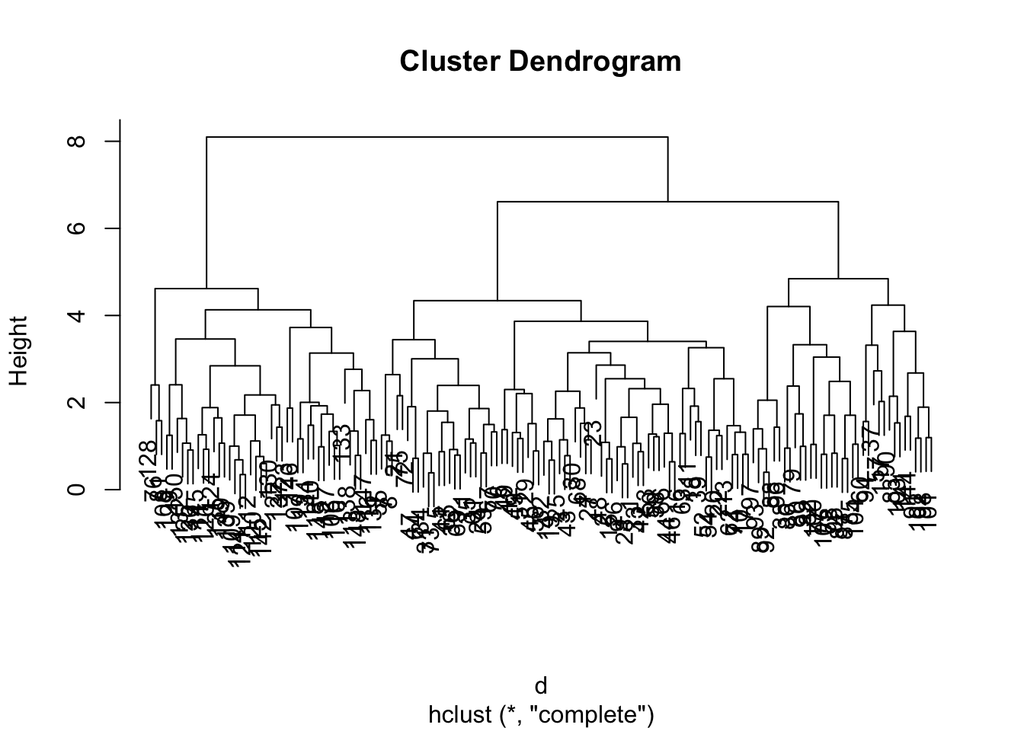

```r
plot(fit)
```

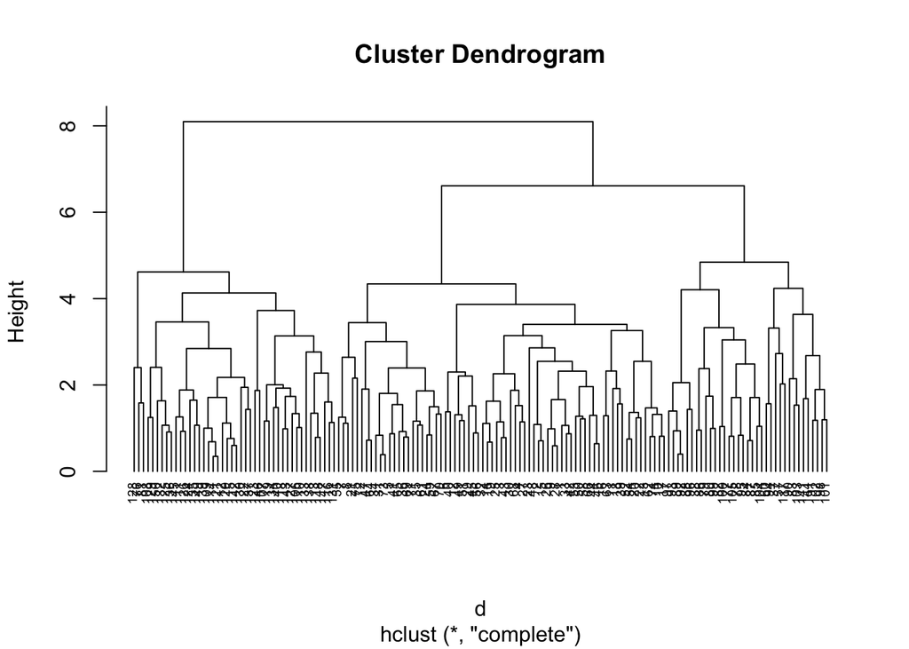

```r
# Added some options to make the graph prettier
plot(fit, hang = -1, cex = 0.6)
```

The dendogram should be read from bottom to top. It shows the history of the hierarchical procedure. The $Y$ axis gives, with a multiplicative factor, the distance between 2 groups. In our case, the graph is not very readable because there is a large number of subjects.

In order to choose the most appropriate number of groups, we can look at the distance measure between the groups when going from $k$ groups to $k-1$ groups. This measure is given in the `height` element of the object returned by `hclust`.

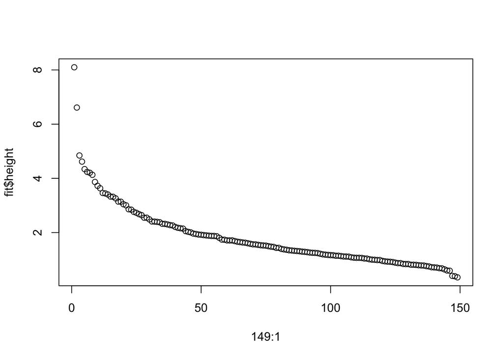

```r
plot(149:1,fit$height)
```

We can see in this graph that there is a big decrease in the inter-group distance when we go from 1 to 3 groups. Then, this decrease is marginal. The idea is generally to choose a small number of groups with a fairly high inter-group distance. So 3 groups seems to be the optimal choice, which is the true number of groups.

If we choose to separate the data into 3 groups, then we need to stop the 3-group hierarchical procedure and then do the assignment of subjects to the 3 groups. This can be done with the following command:

```r
groups=cutree(fit, k=3)
# See the assignment of the first 10 subjects to the 3 groups
groups[1:10]
```

```
##  [1] 1 1 1 1 1 1 1 1 1 1
```

```r
# See the number of subjects in each group
table(groups)
```

```
## groups
##  1  2  3
## 71 35 44
```

We can see that the method classifies 71 subjects in cluster 1, 35 subjects in cluster 2 and 44 subjects in cluster 3. We can also calculate the classification error rate (adjusted rand index) with respect to the “true” groups which are given in the `Cluster` variable. This can be done with the command `rand.index` available in the `fossil` library. The code is as follows:

```r
library(fossil)
adj.rand.index(groups,mydata$Cluster)
```

```
## [1] 0.8542236
```

Here, the adjusted Rand index is 0.85. A value of 1 represents a perfect match between the true groups and the estimated groups. A value of 0 represents a match obtained only by chance.

We can repeat the same analysis using other types of methods, and you will see that the results vary greatly from one method to another:

```r
# Nearest neighbor method
fit = hclust(d, method="single")
groups=cutree(fit, k=3)
table(groups)
```

```
## groups
##   1   2   3
## 103   2  45
```

```r
adj.rand.index(groups,mydata$Cluster)
```

```
## [1] 0.6250776
```

```r
# Average linkage method
fit = hclust(d, method="average")
groups=cutree(fit, k=3)
table(groups)
```

```
## groups
##  1  2  3
## 76 30 44
```

```r
adj.rand.index(groups,mydata$Cluster)
```

```
## [1] 0.9381029
```

```r
# Centroid method
fit = hclust(d, method="centroid")
groups=cutree(fit, k=3)
table(groups)
```

```
## groups
##   1   2   3
## 105  44   1
```

```r
adj.rand.index(groups,mydata$Cluster)
```

```
## [1] 0.6038511
```

```r
# Ward method
fit = hclust(d, method="ward")
```

```
## The "ward" method has been renamed to "ward.D"; note new "ward.D2"
```

```r
groups=cutree(fit, k=3)
table(groups)
```

```
## groups
##  1  2  3
## 76 31 43
```

```r
adj.rand.index(groups,mydata$Cluster)
```

```
## [1] 0.9142436
```

We can see for example that the `centroid` and `single` (nearest neighbor) methods classify the observations into 2 groups rather than 3. Note that it is very common to observe major differences in the results of the different clustering methods. In our example, the `average` method is the one that performs best compared to the true classification, with an adjusted Rand index of 0.93.

### Non-hierarchical methods (k-means)

We will now see the same analyses done with the $k$-mean method. The command to use is `kmeans`, and here is the code below:

```r
# 3 groups
result=kmeans(mydata[,1:6],3)
groups=result$cluster
table(groups)
```

```
## groups
##  1  2  3
## 28 77 45
```

```r
adj.rand.index(groups,mydata$Cluster)
```

```
## [1] 0.9608833
```

We can see that the results differ significantly, compared to the hierarchical algorithms, but in our case the $k$-average method performs better than the hierarchical algorithms. Note also that the `kmeans` command has several options which we will leave to you to study. Note that the different algorithms proposed in the `algorithm` option differ from each other in the way the centroids are updated at each step.

### Effect of standardizing variables

You can also redo the analysis by standardizing the variables and evaluate the difference in the results. The command to standardize variables is `scale` and can be used in the following way:

```r
mydata2=scale(mydata[,1:6],center=TRUE, scale=TRUE)
mydata2=data.frame(mydata2,Cluster=mydata$Cluster)
apply(mydata2,2,mean)
```

```
##        Social     Politique      Horaires      Securite     Publicite
##  1.155172e-16  1.966128e-17  9.950591e-17 -1.053628e-16 -2.025886e-16
##    Reputation       Cluster
##  7.139760e-17  1.800000e+00
```

```r
apply(mydata2,2,sd)
```

```
##     Social  Politique   Horaires   Securite  Publicite Reputation    Cluster
##  1.0000000  1.0000000  1.0000000  1.0000000  1.0000000  1.0000000  0.8747003
```

We can redo all the analyses with the standardized data, using the `rand` index as a performance measure.

```r
# Complete method
d=dist(mydata2[,1:6], method = "euclidean")
fit = hclust(d, method="complete")
groups=cutree(fit, k=3)
adj.rand.index(groups,mydata2$Cluster)
```

```
## [1] 0.8644923
```

```r
# Single method (nearest neighbor)
d=dist(mydata2[,1:6], method = "euclidean")
fit = hclust(d, method="single")
groups=cutree(fit, k=3)
adj.rand.index(groups,mydata2$Cluster)
```

```
## [1] 0.01937268
```

```r
# Average linkage method
d=dist(mydata2[,1:6], method = "euclidean")
fit = hclust(d, method="average")
groups=cutree(fit, k=3)
adj.rand.index(groups,mydata2$Cluster)
```

```
## [1] 0.9381029
```

```r
# Centroid method
d=dist(mydata2[,1:6], method = "euclidian")
fit = hclust(d, method="centroid")
groups=cutree(fit, k=3)
adj.rand.index(groups,mydata2$Cluster)
```

```
## [1] 0.6028777
```

```r
# Ward method
d=dist(mydata2[,1:6], method = "euclidean")
fit = hclust(d, method="ward")
```

```
## The "ward" method has been renamed to "ward.D"; note new "ward.D2"
```

```r
groups=cutree(fit, k=3)
adj.rand.index(groups,mydata2$Cluster)
```

```
## [1] 0.9105762
```

```r
# K-means method
result=kmeans(mydata2[,1:6],3)
groups=result$cluster
adj.rand.index(groups,mydata2$Cluster)
```

```
## [1] 0.9607092
```

We can see that in our case, standardizing the data has almost no impact on the results of all the algorithms, except one: the nearest neighbor method, whose rand index goes from 0.62 to 0.019! We can run this algorithm again to see the classification a little better:

```r
# Single method (nearest neighbor)
d=dist(mydata2[,1:6], method = "euclidean")
fit = hclust(d, method="single")
groups=cutree(fit, k=3)
table(groups)
```

```
## groups
##   1   2   3
## 147   2   1
```

```r
adj.rand.index(groups,mydata2$Cluster)
```

```
## [1] 0.01937268
```

In fact, we can see that the algorithm essentially classifies all the observations in a single group, hence the very low concordance rate with the real groups. Beware, the nearest neighbor method is known to give results that can be very variable… so use with caution.

## Integrated example with a supervised problem

In this example, we will work with data from questionnaires on people’s feelings about the Christmas period. A total of 450 individuals answered 20 questions on a Lickert scale of 1 to 7 (1=not at all and 7=absolutely).

For the first 14 questions, people were asked to indicate whether, on a scale of 1 to 7, Christmas made them feel…

- in a good mood
- annoyed
- happy
- joyful
- disappointed
- delighted
- excited
- sad
- warm
- peaceful
- irritated
- carefree
- light-hearted
- bored

For questions 15-20, people were asked to say whether, on a scale of 1 to 7, the following phrases apply to them:

- When Christmas comes, I follow the seasonal traditions
- I love to store at Christmas
- It’s important to get into the Christmas spirit by participating in organized activities
- Christmas is my favorite time of year
- Christmas shopping is one of the activities I hate the most
- I am very attached to all the Christmas traditions

There is also a variable of interest, Q21, which is the amount of money spent on Christmas this year. The purpose of the analysis is to understand what factors can predict the amount of money spent. Of course, we could run a predictive model with all the variables, but several of them are highly correlated, and the interpretability of the model would be greatly affected.

Instead of using all the variables, we will try 2 strategies: 1) find interpretable factors from the data (factor analysis) and use in the model new variables built from these factors, 2) do a cluster analysis, and see if we can identify interpretable groups that we could use in the analysis.

### Factor analysis

We will start by doing a factor analysis by trying several numbers of factors.

```r
# Read the data
noel=read.csv("Data/christmas.csv")
head(noel)
```

```
##   Q1 Q2 Q3 Q4 Q5 Q6 Q7 Q8 Q9 Q10 Q11 Q12 Q13 Q14 Q15 Q16 Q17 Q18 Q19 Q20    Y
## 1  6  5  6  5  3  7  4  3  4   6   5   4   4   4   4   4   3   3   4   4  513
## 2  3  1  5  5  2  2  3  2  5   7   1   4   5   1   4   3   6   2   5   6 1038
## 3  4  1  5  6  1  6  5  1  6   4   1   4   4   2   7   7   7   7   1   7  569
## 4  7  2  4  5  1  6  2  3  4   3   1   5   6   3   4   4   1   5   4   5  910
## 5  6  3  7  7  5  7  6  2  7   7   3   4   5   1   6   2   5   4   5   4  493
## 6  4  7  4  5  4  2  2  1  4   1   6   5   5   2   2   4   1   1   4   5  732
```

```r
# Remove variable Y for factor analysis
mydata=noel[,-21]

# Factorial analysis
factanal(mydata,1)
```

```
##
## Call:
## factanal(x = mydata, factors = 1)
##
## Uniquenesses:
##    Q1    Q2    Q3    Q4    Q5    Q6    Q7    Q8    Q9   Q10   Q11   Q12   Q13
## 0.957 0.950 0.950 0.984 0.971 0.989 0.980 0.987 0.983 0.976 0.986 0.975 0.986
##   Q14   Q15   Q16   Q17   Q18   Q19   Q20
## 0.995 0.981 0.018 0.958 0.970 0.015 0.985
##
## Loadings:
##     Factor1
## Q1   0.207
## Q2  -0.223
## Q3   0.223
## Q4   0.126
## Q5  -0.171
## Q6   0.107
## Q7   0.141
## Q8  -0.114
## Q9   0.131
## Q10  0.156
## Q11 -0.118
## Q12  0.157
## Q13  0.118
## Q14
## Q15  0.139
## Q16  0.991
## Q17  0.205
## Q18  0.173
## Q19 -0.993
## Q20  0.124
##
##                Factor1
## SS loadings      2.404
## Proportion Var   0.120
##
## Test of the hypothesis that 1 factor is sufficient.
## The chi square statistic is 2531.94 on 170 degrees of freedom.
## The p-value is 0
```

```r
factanal(mydata,2)
```

```
##
## Call:
## factanal(x = mydata, factors = 2)
##
## Uniquenesses:
##    Q1    Q2    Q3    Q4    Q5    Q6    Q7    Q8    Q9   Q10   Q11   Q12   Q13
## 0.948 0.888 0.925 0.957 0.940 0.966 0.924 0.913 0.928 0.950 0.864 0.124 0.005
##   Q14   Q15   Q16   Q17   Q18   Q19   Q20
## 0.957 0.959 0.005 0.942 0.953 0.026 0.978
##
## Loadings:
##     Factor1 Factor2
## Q1   0.104   0.204
## Q2  -0.259  -0.211
## Q3   0.170   0.214
## Q4   0.168   0.121
## Q5  -0.178  -0.169
## Q6   0.155   0.103
## Q7   0.241   0.136
## Q8  -0.275  -0.107
## Q9   0.240   0.118
## Q10  0.167   0.151
## Q11 -0.353  -0.106
## Q12  0.929   0.115
## Q13  0.995
## Q14 -0.198
## Q15  0.141   0.143
## Q16          0.997
## Q17  0.119   0.210
## Q18  0.124   0.178
## Q19         -0.985
## Q20          0.123
##
##                Factor1 Factor2
## SS loadings      2.486   2.363
## Proportion Var   0.124   0.118
## Cumulative Var   0.124   0.242
##
## Test of the hypothesis that 2 factors are sufficient.
## The chi square statistic is 1314.66 on 151 degrees of freedom.
## The p-value is 1.11e-184
```

```r
factanal(mydata,3)
```

```
##
## Call:
## factanal(x = mydata, factors = 3)
##
## Uniquenesses:
##    Q1    Q2    Q3    Q4    Q5    Q6    Q7    Q8    Q9   Q10   Q11   Q12   Q13
## 0.678 0.870 0.675 0.666 0.935 0.694 0.646 0.906 0.551 0.661 0.848 0.112 0.005
##   Q14   Q15   Q16   Q17   Q18   Q19   Q20
## 0.930 0.957 0.005 0.937 0.944 0.025 0.957
##
## Loadings:
##     Factor1 Factor2 Factor3
## Q1   0.542           0.158
## Q2  -0.181  -0.247  -0.190
## Q3   0.531   0.121   0.167
## Q4   0.562   0.113
## Q5  -0.107  -0.173  -0.156
## Q6   0.541   0.101
## Q7   0.559   0.186
## Q8  -0.124  -0.266
## Q9   0.643   0.177
## Q10  0.562   0.112   0.102
## Q11 -0.175  -0.339
## Q12          0.938
## Q13  0.110   0.991
## Q14 -0.190  -0.180
## Q15          0.138   0.134
## Q16                  0.993
## Q17          0.116   0.200
## Q18  0.124   0.117   0.165
## Q19                 -0.981
## Q20  0.162           0.109
##
##                Factor1 Factor2 Factor3
## SS loadings      2.435   2.348   2.216
## Proportion Var   0.122   0.117   0.111
## Cumulative Var   0.122   0.239   0.350
##
## Test of the hypothesis that 3 factors are sufficient.
## The chi square statistic is 728.55 on 133 degrees of freedom.
## The p-value is 6.79e-83
```

```r
factanal(mydata,4)
```

```
##
## Call:
## factanal(x = mydata, factors = 4)
##
## Uniquenesses:
##    Q1    Q2    Q3    Q4    Q5    Q6    Q7    Q8    Q9   Q10   Q11   Q12   Q13
## 0.643 0.597 0.673 0.673 0.672 0.682 0.639 0.714 0.530 0.650 0.585 0.005 0.076
##   Q14   Q15   Q16   Q17   Q18   Q19   Q20
## 0.744 0.935 0.005 0.927 0.925 0.025 0.953
##
## Loadings:
##     Factor1 Factor2 Factor3 Factor4
## Q1   0.583   0.131
## Q2          -0.141           0.606
## Q3   0.537   0.132          -0.144
## Q4   0.545                  -0.163
## Q5          -0.114           0.560
## Q6   0.560
## Q7   0.579           0.123
## Q8                  -0.132   0.513
## Q9   0.671           0.115
## Q10  0.582
## Q11                 -0.163   0.615
## Q12  0.101           0.982  -0.110
## Q13  0.185           0.897  -0.292
## Q14 -0.107                   0.492
## Q15          0.124   0.172  -0.130
## Q16  0.131   0.983          -0.103
## Q17          0.190   0.125  -0.124
## Q18          0.150   0.126  -0.167
## Q19 -0.129  -0.972
## Q20  0.137                  -0.125
##
##                Factor1 Factor2 Factor3 Factor4
## SS loadings      2.509   2.084   1.930   1.821
## Proportion Var   0.125   0.104   0.097   0.091
## Cumulative Var   0.125   0.230   0.326   0.417
##
## Test of the hypothesis that 4 factors are sufficient.
## The chi square statistic is 396.78 on 116 degrees of freedom.
## The p-value is 2.18e-32
```

```r
factanal(mydata,5)
```

```
##
## Call:
## factanal(x = mydata, factors = 5)
##
## Uniquenesses:
##    Q1    Q2    Q3    Q4    Q5    Q6    Q7    Q8    Q9   Q10   Q11   Q12   Q13
## 0.639 0.600 0.670 0.674 0.667 0.681 0.639 0.716 0.532 0.648 0.575 0.005 0.065
##   Q14   Q15   Q16   Q17   Q18   Q19   Q20
## 0.745 0.362 0.023 0.619 0.667 0.005 0.854
##
## Loadings:
##     Factor1 Factor2 Factor3 Factor4 Factor5
## Q1   0.589   0.121
## Q2          -0.124           0.602
## Q3   0.541   0.121          -0.145
## Q4   0.544                  -0.152
## Q5                           0.548  -0.161
## Q6   0.561
## Q7   0.582           0.108
## Q8                  -0.119   0.515
## Q9   0.668
## Q10  0.580
## Q11 -0.107          -0.150   0.625
## Q12  0.115           0.968  -0.128   0.157
## Q13  0.204           0.885  -0.322
## Q14 -0.105                   0.480  -0.113
## Q15                                  0.793
## Q16  0.149   0.955          -0.118   0.167
## Q17                                  0.601
## Q18                         -0.118   0.555
## Q19 -0.149  -0.969           0.117  -0.128
## Q20  0.122                           0.348
##
##                Factor1 Factor2 Factor3 Factor4 Factor5
## SS loadings      2.529   1.927   1.801   1.785   1.574
## Proportion Var   0.126   0.096   0.090   0.089   0.079
## Cumulative Var   0.126   0.223   0.313   0.402   0.481
##
## Test of the hypothesis that 5 factors are sufficient.
## The chi square statistic is 108.31 on 100 degrees of freedom.
## The p-value is 0.268
```

```r
factanal(mydata,6)
```

```
## Error in factanal(mydata, 6): unable to optimize from this starting value
```

```r
print(loadings(factanal(mydata,4)),cutoff=.3)
```

```
##
## Loadings:
##     Factor1 Factor2 Factor3 Factor4
## Q1   0.583
## Q2                           0.606
## Q3   0.537
## Q4   0.545
## Q5                           0.560
## Q6   0.560
## Q7   0.579
## Q8                           0.513
## Q9   0.671
## Q10  0.582
## Q11                          0.615
## Q12                  0.982
## Q13                  0.897
## Q14                          0.492
## Q15
## Q16          0.983
## Q17
## Q18
## Q19         -0.972
## Q20
##
##                Factor1 Factor2 Factor3 Factor4
## SS loadings      2.509   2.084   1.930   1.821
## Proportion Var   0.125   0.104   0.097   0.091
## Cumulative Var   0.125   0.230   0.326   0.417
```

```r
print(loadings(factanal(mydata,5)),cutoff=.3)
```

```
##
## Loadings:
##     Factor1 Factor2 Factor3 Factor4 Factor5
## Q1   0.589
## Q2                           0.602
## Q3   0.541
## Q4   0.544
## Q5                           0.548
## Q6   0.561
## Q7   0.582
## Q8                           0.515
## Q9   0.668
## Q10  0.580
## Q11                          0.625
## Q12                  0.968
## Q13                  0.885  -0.322
## Q14                          0.480
## Q15                                  0.793
## Q16          0.955
## Q17                                  0.601
## Q18                                  0.555
## Q19         -0.969
## Q20                                  0.348
##
##                Factor1 Factor2 Factor3 Factor4 Factor5
## SS loadings      2.529   1.927   1.801   1.785   1.574
## Proportion Var   0.126   0.096   0.090   0.089   0.079
## Cumulative Var   0.126   0.223   0.313   0.402   0.481
```

```r
print(loadings(factanal(mydata,7)),cutoff=.3)
```

```
## Error in factanal(mydata, 7): unable to optimize from this starting value
```

You really have to analyze each solution to see which one interprets best (Wow criterion…). Here we will choose the 5-factor solution. The (subjective) interpretation that we can give to these factors would be the following:

- Bonhomie
- Christmas shopping
- Abandonment to joy
- Abatement
- Christmas ritual

Before constructing new variables for each of these factors, the consistency of the measures within a factor should be checked using Cronbach’s alpha.

```r
library(psy)
cronbach(mydata[,c(1,3,4,6,7,9,10)])
```

```
## $sample.size
## [1] 450
##
## $number.of.items
## [1] 7
##
## $alpha
## [1] 0.7894064
```

```r
cronbach(mydata[,c(16,19)])
```

```
## $sample.size
## [1] 450
##
## $number.of.items
## [1] 2
##
## $alpha
## [1] -118.4787
```

```r
cronbach(mydata[,c(12,13)])
```

```
## $sample.size
## [1] 450
##
## $number.of.items
## [1] 2
##
## $alpha
## [1] 0.9655689
```

```r
cronbach(mydata[,c(2,5,8,11,14)])
```

```
## $sample.size
## [1] 450
##
## $number.of.items
## [1] 5
##
## $alpha
## [1] 0.7050493
```

```r
cronbach(mydata[,c(15,17,18,20)])
```

```
## $sample.size
## [1] 450
##
## $number.of.items
## [1] 4
##
## $alpha
## [1] 0.6753487
```

These results show us that we need to take a closer look at the shopping factor. The two variables being negatively correlated, we will have to reverse the sign of one of the two variables in the calculation of the score.

```r
cor(mydata[,16],mydata[,19])
```

```
## [1] -0.9835252
```

```r
cronbach(cbind(noel[,16],-noel[,19]))
```

```
## $sample.size
## [1] 450
##
## $number.of.items
## [1] 2
##
## $alpha
## [1] 0.9916303
```

Here is the code to create the new variables:

```r
bonhomie=apply(mydata[,c(1,3,4,6,7,9,10)],1,mean)
shopper=(mydata[,16]+8-noel[,19])/2
abandon=apply(mydata[,c(12,13)],1,mean)
dejection=apply(mydata[,c(2,5,8,11,14)],1,mean)
ritualist=apply(mydata[,c(15,17,18,20)],1,mean)
```

Once these scores are created, we can use them in a model to predict the variable $Y$:

```r
factors=data.frame(bonhomie,shopper,abandon,dejection,ritualist)
Y=read.csv("Data/christmas.csv")[,21]
summary(lm(Y~.,data=factors))
```

```
##
## Call:
## lm(formula = Y ~ ., data = factors)
##
## Residuals:
##     Min      1Q  Median      3Q     Max
## -638.21 -256.36    1.38  246.37  701.67
##
## Coefficients:
##             Estimate Std. Error t value Pr(>|t|)
## (Intercept)  220.354    111.382   1.978   0.0485 *
## bonhomie     -31.735     13.740  -2.310   0.0214 *
## shopper       67.899      9.063   7.492  3.7e-13 ***
## abandon      129.142     11.128  11.605  < 2e-16 ***
## dejection      2.944     15.188   0.194   0.8464
## ritualist    -12.843     13.092  -0.981   0.3272
## ---
## Signif. codes:  0 '***' 0.001 '**' 0.01 '*' 0.05 '.' 0.1 ' ' 1
##
## Residual standard error: 308 on 444 degrees of freedom
## Multiple R-squared:  0.3321, Adjusted R-squared:  0.3246
## F-statistic: 44.16 on 5 and 444 DF,  p-value: < 2.2e-16
```

The new variables created seem to explain the amount spent. This can be useful for developing marketing strategies…

Instead of taking the average of the variables of each factor, we could have also calculated a score based on the weights of the factors. The code is then the following:

```r
fanoel=factanal(mydata,5,scores="regression")

# Calculation of new scores for each subject
newfactors=data.frame(fanoel$score)
head(newfactors)
```

```
##       Factor1     Factor2     Factor3    Factor4    Factor5
## 1  0.41889360  0.06661978  0.16535764  1.3026718 -0.6862724
## 2 -0.43521546 -0.74680274 -0.04024076 -1.2100972 -0.3841627
## 3 -0.03156106  1.45058710 -0.49579505 -0.8273063  1.3948600
## 4 -0.31529988 -0.07610286  0.75391462 -0.8042209 -0.9140777
## 5  1.52283133 -1.02623663 -0.10628605  0.1129401 -0.1418901
## 6 -1.20228208  0.38155554  1.19490686  1.1078767 -1.7401183
```

```r
# Correlation between new and average factors
round(cor(fanoel$score,factors),2)
```

```
##         bonhomie shopper abandon dejection ritualist
## Factor1     0.99    0.17    0.18     -0.13      0.09
## Factor2     0.07    0.97    0.03     -0.07      0.08
## Factor3     0.07    0.03    0.95     -0.11      0.07
## Factor4    -0.12   -0.14   -0.27      0.95     -0.14
## Factor5     0.10    0.17    0.14     -0.13      0.95
```

The same analysis can then be repeated:

```r
summary(lm(Y~.,data=newfactors))
```

```
##
## Call:
## lm(formula = Y ~ ., data = newfactors)
##
## Residuals:
##     Min      1Q  Median      3Q     Max
## -634.56 -250.54    4.88  239.05  741.49
##
## Coefficients:
##             Estimate Std. Error t value Pr(>|t|)
## (Intercept)  838.707     14.549  57.648  < 2e-16 ***
## Factor1        7.396     16.506   0.448  0.65429
## Factor2      115.846     14.685   7.889  2.4e-14 ***
## Factor3      173.991     14.700  11.836  < 2e-16 ***
## Factor4      -54.514     17.002  -3.206  0.00144 **
## Factor5       14.585     16.843   0.866  0.38700
## ---
## Signif. codes:  0 '***' 0.001 '**' 0.01 '*' 0.05 '.' 0.1 ' ' 1
##
## Residual standard error: 308.6 on 444 degrees of freedom
## Multiple R-squared:  0.3293, Adjusted R-squared:  0.3217
## F-statistic: 43.59 on 5 and 444 DF,  p-value: < 2.2e-16
```

We see that the results are still quite different, but the $R^2$ of the model is the same.

### Clustering analysis

We will do a cluster analysis with the k-means method, assuming 5 groups (to compare with the factorial analysis)

```r
result=kmeans(mydata,5)
groups=result$cluster
table(groups)
```

```
## groups
##   1   2   3   4   5
##  70  85 109  76 110
```

```r
group1=(groups==1)
tstat=matrix(0,nrow=20,ncol=2)
for (i in 1:20)
{

  tstat[i,]=summary(lm(mydata[,i]~group1))$coefficient[2,c(2,4)]
}
tstat
```

```
##            [,1]         [,2]
##  [1,] 0.2020881 3.715184e-09
##  [2,] 0.1978032 3.026800e-14
##  [3,] 0.2064194 1.200106e-14
##  [4,] 0.2003542 5.528109e-09
##  [5,] 0.1843203 9.088013e-08
##  [6,] 0.2037513 1.996107e-11
##  [7,] 0.2192586 2.144404e-10
##  [8,] 0.2007807 1.028746e-05
##  [9,] 0.2116537 7.591047e-22
## [10,] 0.2071949 1.460039e-16
## [11,] 0.2067479 4.414766e-15
## [12,] 0.1804592 5.814352e-11
## [13,] 0.1747865 1.422921e-14
## [14,] 0.1603296 1.460067e-10
## [15,] 0.2194760 4.996402e-15
## [16,] 0.2173929 1.139340e-06
## [17,] 0.2125426 6.343393e-12
## [18,] 0.2020884 9.921145e-16
## [19,] 0.2138319 8.904907e-07
## [20,] 0.1703172 1.207962e-07
```

The results are not very conclusive for group 1, it is difficult to see which variables are the most discriminating. If we run the same code again for the other groups (results not shown here), it is more or less the same, except for group 3 which seems to represent people who like shopping.

We can still try to see if group membership has any predictive power on the variable $Y$:

```r
groups=as.factor(groups)
summary(lm(Y~groups))
```

```
##
## Call:
## lm(formula = Y ~ groups)
##
## Residuals:
##     Min      1Q  Median      3Q     Max
## -840.53 -267.76    8.99  247.12  931.34
##
## Coefficients:
##             Estimate Std. Error t value Pr(>|t|)
## (Intercept)   681.36      42.74  15.941  < 2e-16 ***
## groups2       191.08      57.72   3.310  0.00101 **
## groups3       170.17      54.77   3.107  0.00201 **
## groups4        16.09      59.24   0.272  0.78606
## groups5       316.31      54.68   5.785 1.37e-08 ***
## ---
## Signif. codes:  0 '***' 0.001 '**' 0.01 '*' 0.05 '.' 0.1 ' ' 1
##
## Residual standard error: 357.6 on 445 degrees of freedom
## Multiple R-squared:  0.09744,    Adjusted R-squared:  0.08932
## F-statistic: 12.01 on 4 and 445 DF,  p-value: 2.814e-09
```

Note that putting the group index in a prediction model can sometimes be a good strategy (even if it is not the case here)…